# Part II: Serovar Specific DESeq: Salmonella Heidelberg

# Correlation Heatmap

### *Pairwise 3 : Iso 4 v Iso 5*

This will visualize the relationship between the samples.

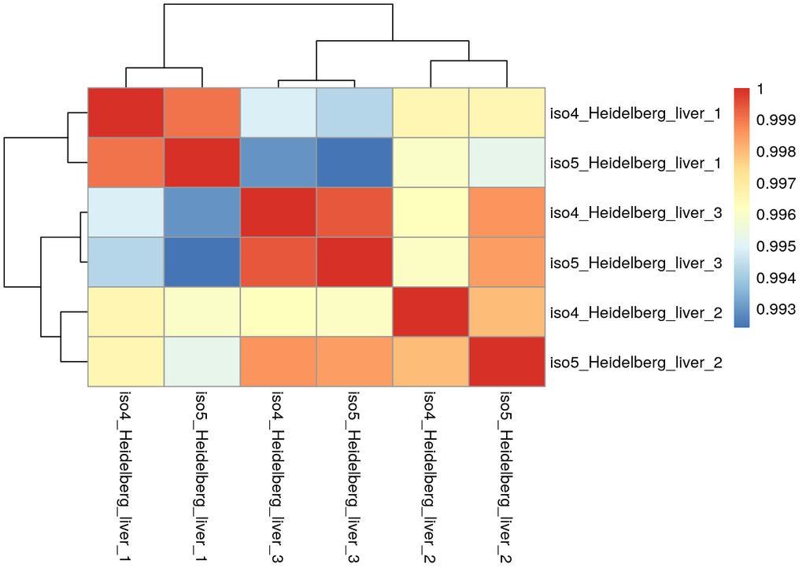

```r
#plot correlation heatmap
rld <- rlog(ddsHTSeq_heidelberg_4v5, blind=FALSE)
rld_mat <- assay(rld)
rld_cor <- cor(rld_mat)
pheatmap(rld_cor)
```

```r
ggsave("Heidelberg_4v5_CorHeatMap.png")
```

**Figure 18. Correlation heatmap of three replicates of Iso 4 (Kosher liver, fresh) and Iso 5 (Kosher liver, broiled).** This heatmap shows that the isolates are very similar, as a value of 1 indicates that 1 is most similar, and 0.993 is least similar. In fact, it seems that isolates of different sources are similar based upon replicate number, potentially moreso than source.

Since there are no DE genes between Iso 4 and Iso 5, I will not proceed with data visualization.

# Conclusion

I hypothesized that isolates 4 and 5 would be very different from isolate 1, as they are from different outbreaks. These differences were likely due to genetic variability among the isolates. This was supported by my findings, as there were 120 DE genes in *both* Iso 4 and Iso 5 when compared to Iso 1. Likewise, there were 0 DE genes between Iso 4 and Iso 5. This emphasizes the point that neither the source (fresh versus broiled liver) nor the heat tolerance (as determined by wet lab experiments) had significant impacts on gene expression. However, it was interesting to see that genes encoding for antimicrobial resistance were upregulated in Iso 1 (*tet(B)* was the third most upregulated gene when compared to Iso 4; *APH(6)* was the most upregulated gene when compared to Iso 5; both AMR genes were DE in both pairwise comparisons).

Because Salmonella enterica is a non-model organism, there were limitations inherent in this study, such as the lack of gene annotation, but there were also unanticipated road blocks. Using a serovar-specific alignment was useful in enhancing specificity, but lack of annotation made it difficult to conceptualize the functions of differentially expressed genes. Furthermore, we were unable to convert the gene id’s to the formats necessary for either gene ontology or KEGG analysis. Within this serovar-specific analysis of the Heidelberg isolates, we were still able to see the upregulation of AMR genes, which supports and validates the outbreak and clinical manifestations of Isolate 1, from the Foster Farms chicken outbreak. Manually annotating and analyzing DE genes was time consuming and less effective than other methods, and better pipelines for evaluating DESEq results within specific *Salmonella enterica* serovars would prove useful.